# DATA MINING: FIFA 19

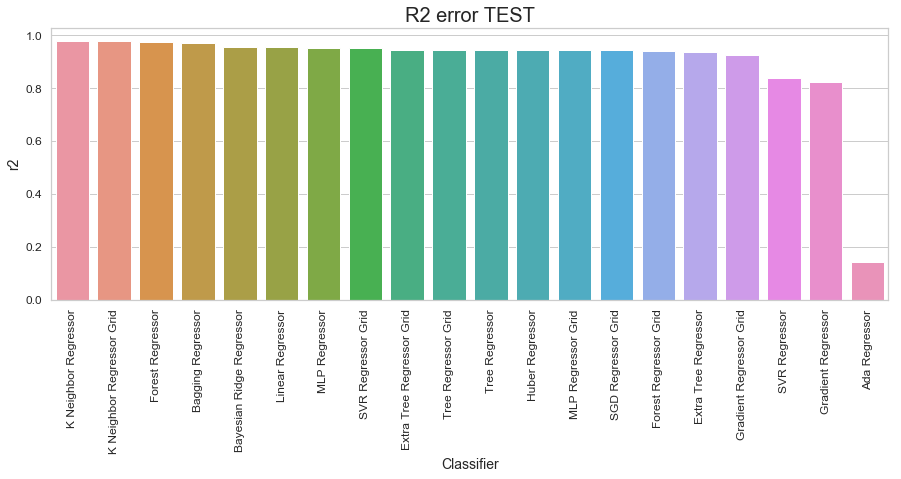

```python
plt.figure(figsize=(15,5))
a = scores_test.sort_values(by = 'r2', ascending = False)
p = sns.barplot(x = a.Classifier, y = a.r2)
p = plt.xticks(rotation=90)
plt.title("R2 error TEST", size=20)
# save_fig("R2 error TEST")
```

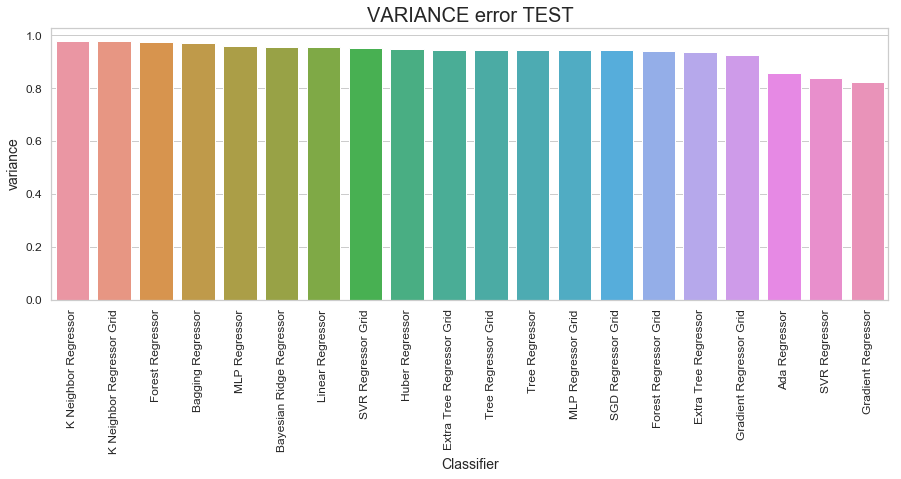

```python
plt.figure(figsize=(15,5))
a = scores_test.sort_values(by = 'variance', ascending = False)
p = sns.barplot(x = a.Classifier, y = a.variance)
p = plt.xticks(rotation=90)
plt.title("VARIANCE error TEST", size=20)
# save_fig("VARIANCE error TEST")
```

Facendo riferimento al test_set, si nota come il modello K Neighbor Regressor (sia normale che Grid) sia quello che fornisce i valori di R2 e Variance più alti ed errori più bassi (secondo solo per il Mean Absoulute Error). I peggiori, in termini di errori e di predizioni corrette, trascurando SGD e Radius Neighbor, possono essere considerati l'Ada Regressor, il Gradient Regressor e il SVR Regressor. Sul train_set, invece, i regressori basati su albero sembrano comportarsi meglio. Bene anche i regressori ensamble basati, però, sul *bagging*.

Segue un confronto tra gli errori commessi sul train set e sul test set. Verrano presi, a titolo esplicativo, le misure *mse* e *r2*.

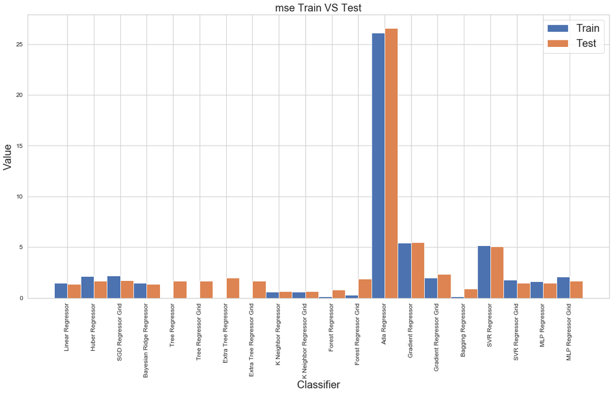

```python
train_mse = scores_train.mse.values.tolist()
test_mse = scores_test.mse.values.tolist()

fig, ax = plt.subplots(figsize=(20,10))
width = 0.50
i = np.arange(len(train_mse))
train_bars = ax.bar(i, train_mse , width,)
test_bars = ax.bar(i+width, test_mse , width)

ax.set_xlabel("Classifier",fontsize=20)

ax.set_ylabel('Value',fontsize=20)
ax.set_title('mse Train VS Test',fontsize=20)
ax.set_xticklabels(scores_train.Classifier, rotation = 90)
ax.set_xticks(i + width / 2)

ax.legend((train_bars,test_bars),('Train','Test'),fontsize=20)
plt.show()
# save_fig("mse Train VS Test")
```

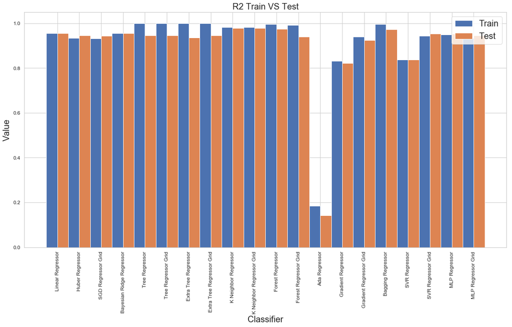

```python
train_r2 = scores_train.r2.values.tolist()
test_r2 = scores_test.r2.values.tolist()

fig, ax = plt.subplots(figsize=(20,10))
width = 0.50
i = np.arange(len(train_r2))
train_bars = ax.bar(i, train_r2 , width,)
test_bars = ax.bar(i+width, test_r2 , width)

ax.set_xlabel("Classifier",fontsize=20)

ax.set_ylabel('Value',fontsize=20)
# plt.yticks([1,0.99,0.995,0.985])
ax.set_title('R2 Train VS Test',fontsize=20)
ax.set_xticklabels(scores_train.Classifier, rotation = 90)
ax.set_xticks(i + width / 2)

ax.legend((train_bars,test_bars),('Train','Test'),fontsize=20)
plt.show()
# save_fig("R2 Train VS Test")
```

Com'era normale aspettarsi, sul test set si ottengono risultati leggermente peggiori, dovuti al fatto che il train set è il dataset su cui gli algoritmi si sono addestrati. Nonostante ciò, non si notano grandi differenze tra test e train, concludendo quindi che il processo di regressione è corretto. Non si notano, inoltre, particolari fenomeni di overfitting.